[figure not shown]

# **Reproducible report**

#### **Sofya Aksenyuk, 150284; Uladzimir Ivashka, 150281**

### **Executive summary**

#### The following report examines various aspects of Stock Market, namely:

- Gold
- Bitcoin
- Currency
- S&P Composite
- Traded shares

#### within specific time intervals.

#### Now, let’s elaborate on each of the listed points.

### **Gold prices**

#### The examination below presents the comparison between morning and evening gold prices with respect to three different currencies (namely, USD, EUR, GBP) in the time interval from 1968 to 2021.

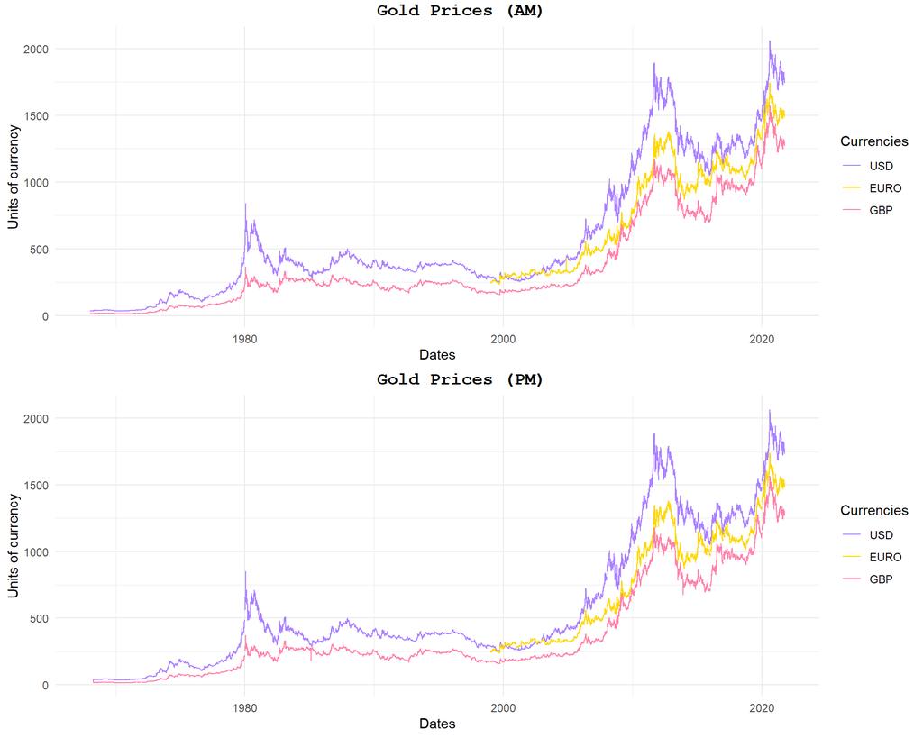

```r
one <- ggplot(am, aes(x=as.Date(Date, "%Y-%m-%d"), group = 1)) +
  geom_line(aes(y=USD, color = 'USD')) +
  geom_line(aes(y=EURO, color='EURO')) +
  geom_line(aes(y=GBP, color='GBP')) +
  labs(y='Units of currency', x='Dates', color='Currencies') +
  theme_minimal() +
  scale_color_manual(values = colors)

plot1_1 <- annotate_figure(one, top = text_grob("Gold Prices (AM)", face = "bold", size = 14, family = "mono"))

two <- ggplot(pm, aes(x=as.Date(Date.1, "%Y-%m-%d"), group = 1)) +
  geom_line(aes(y=USD.1, color = 'USD')) +
  geom_line(aes(y=EURO.1, color='EURO')) +
  geom_line(aes(y=GBP.1, color='GBP')) +
  labs(y='Units of currency', x='Dates', color='Currencies') +
  theme_minimal() +
  scale_color_manual(values = colors)

plot1_2 <- annotate_figure(two, top = text_grob("Gold Prices (PM)", face = "bold", size = 14, family = "mono"))

ggarrange(plot1_1, plot1_2, nrow=2, common.legend = TRUE, legend = "right")
```

#### **Observations:** It can be noticed that gold prices increased dramatically within the given time period. However, the difference between morning (AM) and evening (PM) change can be hardly seen.

### **Bitcoin**

#### The plots below show the statistics of Bitcoin Exchange Trade Volume and Bitcoin Market Price with respect to USD from 2016 to 2021.

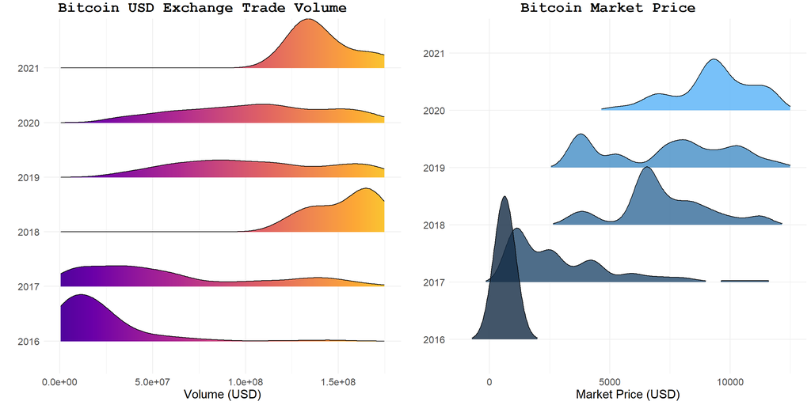

```r
pl <- ggplot(bch_data, aes(x = trade, y = factor(Year), fill = ..x..)) +
  geom_density_ridges_gradient(scale = .9, gradient_lwd = .5,
                               color = "black", show.legend = FALSE) +
  scale_fill_viridis_c(option = "plasma", name = "") +
  theme_minimal() +
  theme(text = element_text(size=15)) +
  xlim(0, 175000000) +
  labs(x='Volume (USD)', y='')
plot_tr <- annotate_figure(pl, top = text_grob("Bitcoin USD Exchange Trade Volume", face = "bold", size = 18, family = "mono"))

pl2 <- ggplot(bch_data, aes(x = market, y = factor(Year), fill = Year)) +
  geom_density_ridges(alpha = .8, color = "black",
                      scale = 2.5, rel_min_height = .01) +
  labs(x = "Market Price (USD)", y = "") +
  guides(fill = FALSE) +
  theme_minimal() +
  theme(text = element_text(size=15)) +
  xlim(-1000, 12500)

plot_market <- annotate_figure(pl2, top = text_grob("Bitcoin Market Price", face = "bold", size = 18, family = "mono"))

ggarrange(plot_tr, plot_market, ncol=2)
```

#### It is necessary to give a separate plot for Market Price in 2021 since its increasing trend led to the enormously higher value range.

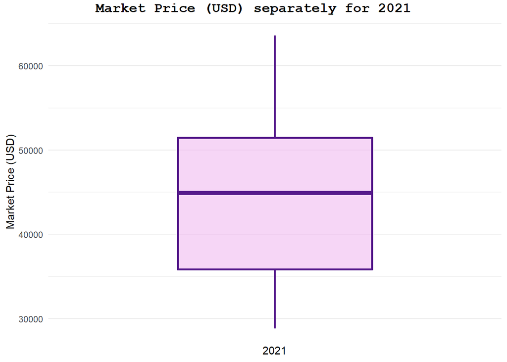

```r
sep_mark <- ggplot(bch_data_sep, aes(y=market)) +
  geom_boxplot(aes(x=Year), color="purple4", fill="plum2", alpha=0.5, size=1) +
  scale_x_discrete(labels= "2021") +
  theme_minimal() +
  labs(x = "2021", y = "Market Price (USD)") +
  theme(legend.position="none")

annotate_figure(sep_mark, top = text_grob("Market Price (USD) separately for 2021", face = "bold", size = 14, family = "mono"))
```

#### **Observations:** Both - Bitcoin Exchange Trade Volume and Market Price experienced significant grow by the end of 2021.